# Instantaneous network model diagnostics - test risk group tersm

This file shows diagnostics for instantaneous network models. Here we test whether we can fit a model with only edges + nodefactor(“riskg”) to see if the risk group definitions are problematic independent of other terms in the model. We try fitting these: 1) using the original target statistics from the data, where the lowest groups have 0 instantaneous partnerships. This model includes the offset for role class. 2) With a dummy network of 10,000 with four equally sized risk groups. The total number of edges corresponds to that in the data, but the target stats for `nodefactor(riskg)` are set arbitrarily and range from 0 to >80% of total degree. In this first model, the highest group is the reference level and we do not include an offset for role class. 3) Using the dummy network and target statistics defined above but with the lowest quartile set to the reference group. 4) Using model 2 but including the offsets for role class.

## Load packages and model fits

```r
rm(list = ls())
suppressMessages(library("EpiModelHIV"))
library("latticeExtra")
library("knitr")
library("kableExtra")
library("here")
load(file = here("Model fits and simulations/Fit tests and debugging/est/fit.i.testriskg_zeros.bal.rda"))
load(file = here("Model fits and simulations/Fit tests and debugging/est/fit.i.testriskg_fakegroups.bal.rda"))
```

## 0. Edges + offset(nodematch(“role.class”))

This first model just includes a term for edges and an offset for role class, for comparison with the models that incorporate nodefactor terms for risk groups.

### Model terms and control settings

| Terms | Target stats |
| --- | --- |
| edges | 479.2 |

The control settings for these models are:

```r
set.control.ergm = control.ergm(MCMC.interval = 1e+5,
                                MCMC.samplesize = 7500,
                                MCMC.burnin = 1e+6,
                                MPLE.max.dyad.types = 1e+7,
                                MCMLE.maxit = 400,
                                parallel = np/2,
                                parallel.type="PSOCK"))
```

### MCMC diagnostics

```
## Sample statistics summary:
##
## Iterations = 1e+06:375900000
## Thinning interval = 1e+05
## Number of chains = 8
## Sample size per chain = 3750
##
## 1. Empirical mean and standard deviation for each variable,
##    plus standard error of the mean:
##
##           Mean             SD       Naive SE Time-series SE
##        -1.2820        21.9669         0.1268         0.1282
##
## 2. Quantiles for each variable:
##
##     2.5%      25%      50%      75%    97.5%
## -44.8414 -15.8414  -0.8414  13.1586  41.1586
##
##
## Sample statistics cross-correlations:
##       edges
## edges     1
##
## Sample statistics auto-correlation:
## Chain 1
##                 edges
## Lag 0      1.00000000
## Lag 1e+05 -0.01337422
## Lag 2e+05  0.02578163
## Lag 3e+05 -0.02321045
## Lag 4e+05 -0.01279338
## Lag 5e+05 -0.02959366
## Chain 2
##                 edges
## Lag 0      1.00000000
## Lag 1e+05 -0.01663722
## Lag 2e+05  0.01984823
## Lag 3e+05  0.01125878
## Lag 4e+05  0.03008950
## Lag 5e+05 -0.01901362
```

[output cut: 131 more lines]

```
##      edges
## 0.08120044
## Joint P-value (lower = worse):  0.08631947 .
## Chain 8
##
## Fraction in 1st window = 0.1
## Fraction in 2nd window = 0.5
##
##    edges
## -0.04784
##
## Individual P-values (lower = worse):
##     edges
## 0.9618427
## Joint P-value (lower = worse):  0.9569976 .
```

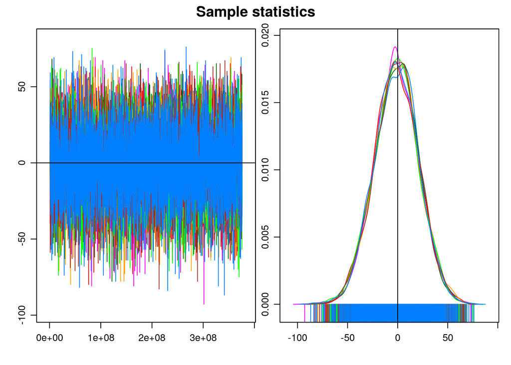

```
##
## MCMC diagnostics shown here are from the last round of simulation, prior to computation of final parameter estimates. Because the final estimates are refinements of those used for this simulation run, these diagnostics may understate model performance. To directly assess the performance of the fi…
```

### Summary of model fit

```r
summary(est.i.testriskg_fakegroups[[4]])
```

```
##
## ==========================
## Summary of model fit
## ==========================
##
## Formula:   nw ~ edges + offset(nodematch("role.class", diff = TRUE, keep = 1:2))
## <environment: 0x564f587f8f28>
##
## Iterations:  2 out of 400
##
## Monte Carlo MLE Results:
##                                 Estimate Std. Error MCMC % z value
## edges                          -11.48529    0.04552      0  -252.3
## offset(nodematch.role.class.I)      -Inf    0.00000      0    -Inf
## offset(nodematch.role.class.R)      -Inf    0.00000      0    -Inf
##                                Pr(>|z|)
## edges                            <1e-04 ***
## offset(nodematch.role.class.I)   <1e-04 ***
## offset(nodematch.role.class.R)   <1e-04 ***
## ---
## Signif. codes:  0 '***' 0.001 '**' 0.01 '*' 0.05 '.' 0.1 ' ' 1
##
## Log-likelihood was not estimated for this fit.
## To get deviances, AIC, and/or BIC from fit `object$fit` run
##   > object$fit<-logLik(object$fit, add=TRUE)
## to add it to the object or rerun this function with eval.loglik=TRUE.
##
##  The following terms are fixed by offset and are not estimated:
##   offset(nodematch.role.class.I) offset(nodematch.role.class.R)
##
##
## Dissolution Coefficients
## =======================
## Dissolution Model: ~offset(edges)
## Target Statistics: 1
## Crude Coefficient: -Inf
## Mortality/Exit Rate: 0
## Adjusted Coefficient: -Inf
```

### Network diagnostics

```r
(dx0 <- netdx(est.i.testriskg_fakegroups[[4]], nsims = 10, nsteps = 1000, ncores = 4, set.control.ergm = control.simulate.ergm(MCMC.interval = 1e+5, MCMC.burnin = 1e+6)))
```

```
##
## Network Diagnostics
## -----------------------
## - Simulating 10 networks
## - Calculating formation statistics
## - Calculating duration statistics
## - Calculating dissolution statistics
##
```

```
## EpiModel Network Diagnostics
## =======================
## Diagnostic Method: Dynamic
## Simulations: 10
## Time Steps per Sim: 1000
##
## Formation Diagnostics
## -----------------------
##                                 Target Sim Mean Pct Diff Sim SD
## edges                          479.159  479.294        0  21.88
## offset(nodematch.role.class.I)      NA    0.000       NA   0.00
## offset(nodematch.role.class.R)      NA    0.000       NA   0.00
##
## Dissolution Diagnostics
## -----------------------
##                Target Sim Mean Pct Diff Sim SD
## Edge Duration       1        1        0      0
## Pct Edges Diss      1        1        0      0
```

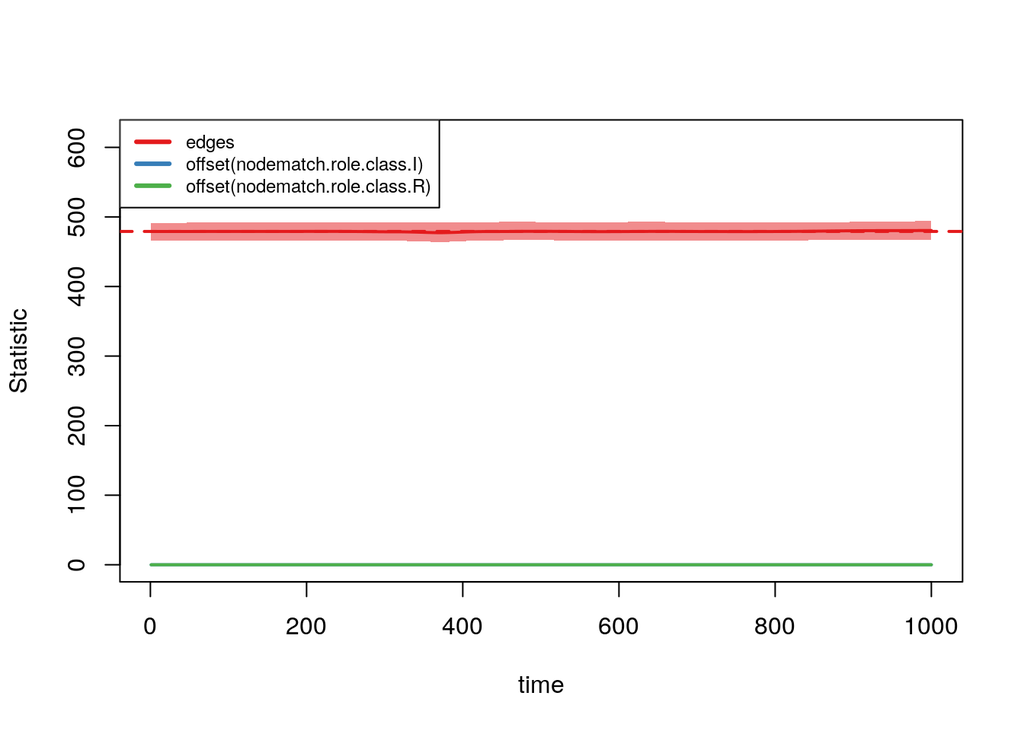

```r
plot(dx0, type="formation")
```

```r
plot(dx0, type="duration")
```

```r
plot(dx0, type="dissolution")
```

## 1. Edges + nodefactor(“riskg”) + offset(nodematch(“role.class”))

This model uses the risk groups we want to include in the model with the target stats from the data.

### Model terms and control settings

[output not shown]

The control settings for these models are:

```r
set.control.ergm = control.ergm(MCMC.interval = 1e+5,
                                MCMC.samplesize = 7500,
                                MCMC.burnin = 1e+6,
                                MPLE.max.dyad.types = 1e+7,
                                MCMLE.maxit = 400,
                                parallel = np/2,
                                parallel.type="PSOCK"))
```

### MCMC diagnostics

```
## Sample statistics summary:
##
## Iterations = 1e+06:375900000
## Thinning interval = 1e+05
## Number of chains = 8
## Sample size per chain = 3750
##
## 1. Empirical mean and standard deviation for each variable,
##    plus standard error of the mean:
##
##                         Mean     SD Naive SE Time-series SE
## edges               -3.53211 21.928  0.12660        0.12603
## nodefactor.riskg.O3 -0.06555  2.630  0.01518        0.01539
## nodefactor.riskg.O4 -0.53450 11.030  0.06368        0.06369
## nodefactor.riskg.Y2  0.10861  2.854  0.01648        0.01699
## nodefactor.riskg.Y3 -0.43293  8.743  0.05047        0.05027
##
## 2. Quantiles for each variable:
##
##                        2.5%     25%     50%    75%  97.5%
## edges               -46.841 -17.841 -3.8414 11.159 39.159
## nodefactor.riskg.O3  -5.144  -2.144 -0.1442  1.856  4.856
## nodefactor.riskg.O4 -22.487  -7.487 -0.4873  6.513 20.513
## nodefactor.riskg.Y2  -5.798  -1.798  0.2024  2.202  5.202
## nodefactor.riskg.Y3 -18.214  -6.214 -0.2140  5.786 15.786
##
##
## Sample statistics cross-correlations:
##                         edges nodefactor.riskg.O3 nodefactor.riskg.O4
## edges               1.0000000         0.123720771          0.44337703
## nodefactor.riskg.O3 0.1237208         1.000000000          0.03612172
## nodefactor.riskg.O4 0.4433770         0.036121722          1.00000000
## nodefactor.riskg.Y2 0.1405387         0.003047723          0.02362325
## nodefactor.riskg.Y3 0.3713662         0.024971557          0.07396734
##                     nodefactor.riskg.Y2 nodefactor.riskg.Y3
## edges                       0.140538750          0.37136618
## nodefactor.riskg.O3         0.003047723          0.02497156
## nodefactor.riskg.O4         0.023623245          0.07396734
## nodefactor.riskg.Y2         1.000000000          0.03386385
## nodefactor.riskg.Y3         0.033863847          1.00000000
```

[output cut: 237 more lines]

```
##
## Fraction in 1st window = 0.1
## Fraction in 2nd window = 0.5
##
##               edges nodefactor.riskg.O3 nodefactor.riskg.O4
##              2.2147              0.9152              0.6752
## nodefactor.riskg.Y2 nodefactor.riskg.Y3
##             -1.6135             -0.6540
##
## Individual P-values (lower = worse):
##               edges nodefactor.riskg.O3 nodefactor.riskg.O4
##          0.02678236          0.36010492          0.49951929
## nodefactor.riskg.Y2 nodefactor.riskg.Y3
##          0.10663064          0.51311388
## Joint P-value (lower = worse):  0.05033949 .
```

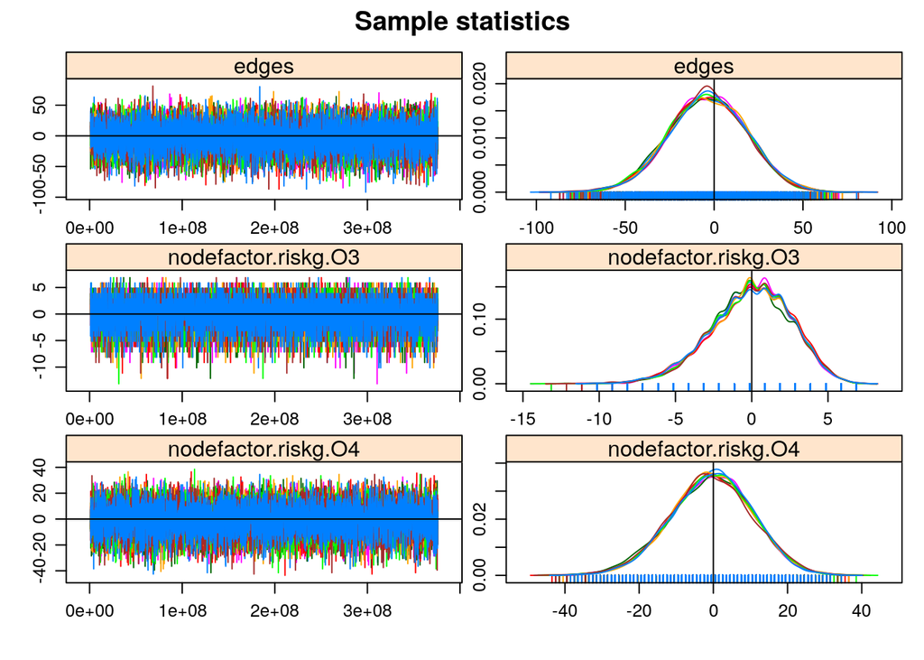

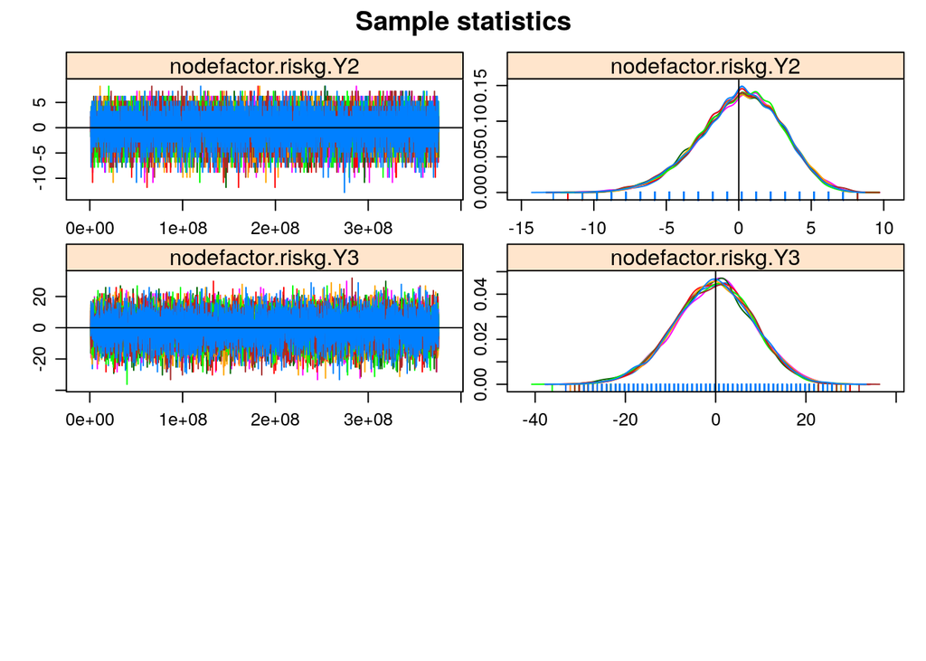

```
##
## MCMC diagnostics shown here are from the last round of simulation, prior to computation of final parameter estimates. Because the final estimates are refinements of those used for this simulation run, these diagnostics may understate model performance. To directly assess the performance of the fi…
```

### Summary of model fit

```r
summary(est.i.testriskg_zeros.bal)
```

```
##
## ==========================
## Summary of model fit
## ==========================
##
## Formula:   nw ~ edges + nodefactor("riskg", base = 8) + offset(nodematch("role.class",
##     diff = TRUE, keep = 1:2))
## <environment: 0x564f1d66ab50>
##
## Iterations:  2 out of 400
##
## Monte Carlo MLE Results:
##                                Estimate Std. Error MCMC %  z value
## edges                          -8.65290    0.05597      0 -154.606
## nodefactor.riskg.O1                -Inf    0.00000      0     -Inf
## nodefactor.riskg.O2                -Inf    0.00000      0     -Inf
## nodefactor.riskg.O3            -3.49589    0.38350      0   -9.116
## nodefactor.riskg.O4            -0.72313    0.10189      0   -7.097
## nodefactor.riskg.Y1                -Inf    0.00000      0     -Inf
## nodefactor.riskg.Y2            -4.52490    0.35437      0  -12.769
## nodefactor.riskg.Y3            -2.37453    0.12401      0  -19.147
## offset(nodematch.role.class.I)     -Inf    0.00000      0     -Inf
## offset(nodematch.role.class.R)     -Inf    0.00000      0     -Inf
##                                Pr(>|z|)
## edges                            <1e-04 ***
## nodefactor.riskg.O1              <1e-04 ***
## nodefactor.riskg.O2              <1e-04 ***
## nodefactor.riskg.O3              <1e-04 ***
## nodefactor.riskg.O4              <1e-04 ***
## nodefactor.riskg.Y1              <1e-04 ***
## nodefactor.riskg.Y2              <1e-04 ***
## nodefactor.riskg.Y3              <1e-04 ***
## offset(nodematch.role.class.I)   <1e-04 ***
## offset(nodematch.role.class.R)   <1e-04 ***
## ---
## Signif. codes:  0 '***' 0.001 '**' 0.01 '*' 0.05 '.' 0.1 ' ' 1
##
## Log-likelihood was not estimated for this fit.
## To get deviances, AIC, and/or BIC from fit `object$fit` run
##   > object$fit<-logLik(object$fit, add=TRUE)
## to add it to the object or rerun this function with eval.loglik=TRUE.
##
##  Warning: The following terms have infinite coefficient estimates:
##   nodefactor.riskg.O1 nodefactor.riskg.O2 nodefactor.riskg.Y1
##
##  The following terms are fixed by offset and are not estimated:
##   offset(nodematch.role.class.I) offset(nodematch.role.class.R)
##
##
## Dissolution Coefficients
## =======================
## Dissolution Model: ~offset(edges)
## Target Statistics: 1
## Crude Coefficient: -Inf
## Mortality/Exit Rate: 0
## Adjusted Coefficient: -Inf
```

### Network diagnostics

```r
(dx1 <- netdx(est.i.testriskg_zeros.bal, nsims = 10, nsteps = 1000, ncores = 4, set.control.ergm = control.simulate.ergm(MCMC.interval = 1e+5, MCMC.burnin = 1e+6)))
```

```
##
## Network Diagnostics
## -----------------------
## - Simulating 10 networks
## - Calculating formation statistics
## - Calculating duration statistics
## - Calculating dissolution statistics
##
```

```
## EpiModel Network Diagnostics
## =======================
## Diagnostic Method: Dynamic
## Simulations: 10
## Time Steps per Sim: 1000
##
## Formation Diagnostics
## -----------------------
##                                 Target Sim Mean Pct Diff Sim SD
## edges                          479.159  382.860   -0.201 38.922
## nodefactor.riskg.O1                 NA    0.000       NA  0.000
## nodefactor.riskg.O2                 NA    0.000       NA  0.000
## nodefactor.riskg.O3              6.856    6.859    0.001  2.631
## nodefactor.riskg.O4            109.513  101.514   -0.073 12.015
## nodefactor.riskg.Y1                 NA    0.000       NA  0.000
## nodefactor.riskg.Y2              8.202    8.191   -0.001  2.899
## nodefactor.riskg.Y3             70.786   70.841    0.001  8.814
## offset(nodematch.role.class.I)      NA    0.000       NA  0.000
## offset(nodematch.role.class.R)      NA    0.000       NA  0.000
##
## Dissolution Diagnostics
## -----------------------
##                Target Sim Mean Pct Diff Sim SD
## Edge Duration       1        1        0      0
## Pct Edges Diss      1        1        0      0
```

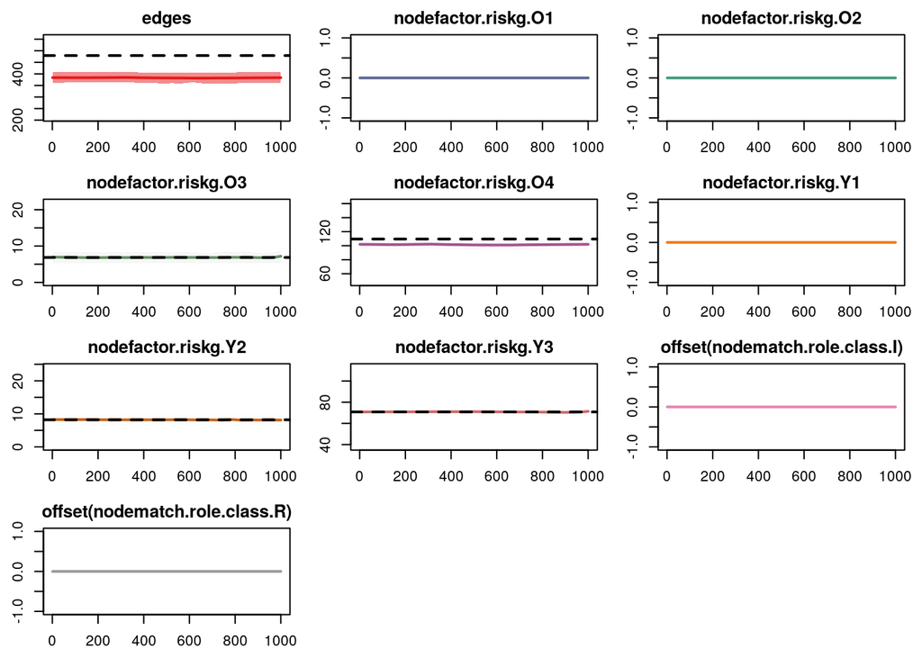

```r
plot(dx1, type="formation")
```

```r
plot(dx1, type="duration")
```

```r
plot(dx1, type="dissolution")
```

## 2. Edges + nodefactor(“group”, base=4)

This model uses the made-up four risk groups with the highest quartile set to the reference group.

### Model terms and control settings

| Terms | Target stats |
| --- | --- |
| edges | 479.2 |
| nodefactor.groups.G1 | 0.0 |
| nodefactor.groups.G2 | 10.0 |
| nodefactor.groups.G3 | 100.0 |

The control settings for these models are:

```r
set.control.ergm = control.ergm(MCMC.interval = 1e+5,
                                MCMC.samplesize = 7500,
                                MCMC.burnin = 1e+6,
                                MPLE.max.dyad.types = 1e+7,
                                MCMLE.maxit = 400,
                                parallel = np/2,
                                parallel.type="PSOCK"))
```

### MCMC diagnostics

```
## Sample statistics summary:
##
## Iterations = 1e+06:375900000
## Thinning interval = 1e+05
## Number of chains = 8
## Sample size per chain = 3750
##
## 1. Empirical mean and standard deviation for each variable,
##    plus standard error of the mean:
##
##                         Mean     SD Naive SE Time-series SE
## edges                -0.1877 21.872  0.12628        0.12555
## nodefactor.groups.G2 -0.0533  3.203  0.01849        0.01840
## nodefactor.groups.G3 -0.1204 10.551  0.06092        0.06122
##
## 2. Quantiles for each variable:
##
##                        2.5%    25%    50%   75% 97.5%
## edges                -43.84 -14.84 0.1586 14.16 42.16
## nodefactor.groups.G2  -7.00  -2.00 0.0000  2.00  6.00
## nodefactor.groups.G3 -21.00  -7.00 0.0000  7.00 20.00
##
##
## Sample statistics cross-correlations:
##                          edges nodefactor.groups.G2 nodefactor.groups.G3
## edges                1.0000000           0.14826825           0.44386913
## nodefactor.groups.G2 0.1482682           1.00000000           0.02359178
## nodefactor.groups.G3 0.4438691           0.02359178           1.00000000
##
## Sample statistics auto-correlation:
## Chain 1
##                   edges nodefactor.groups.G2 nodefactor.groups.G3
## Lag 0      1.0000000000          1.000000000          1.000000000
## Lag 1e+05 -0.0086882502          0.003781517         -0.004609551
## Lag 2e+05 -0.0004484220         -0.004336004         -0.033288317
## Lag 3e+05  0.0041756228         -0.013786704          0.032697274
## Lag 4e+05  0.0046229243         -0.013816962         -0.012973110
## Lag 5e+05 -0.0005360254          0.005987317          0.007084957
## Chain 2
##                   edges nodefactor.groups.G2 nodefactor.groups.G3
```

[output cut: 137 more lines]

```
##                edges nodefactor.groups.G2 nodefactor.groups.G3
##            0.2137651            0.3535981            0.9525152
## Joint P-value (lower = worse):  0.4576919 .
## Chain 8
##
## Fraction in 1st window = 0.1
## Fraction in 2nd window = 0.5
##
##                edges nodefactor.groups.G2 nodefactor.groups.G3
##              -0.5347              -2.4369              -0.5394
##
## Individual P-values (lower = worse):
##                edges nodefactor.groups.G2 nodefactor.groups.G3
##           0.59286857           0.01481418           0.58963874
## Joint P-value (lower = worse):  0.1611006 .
```

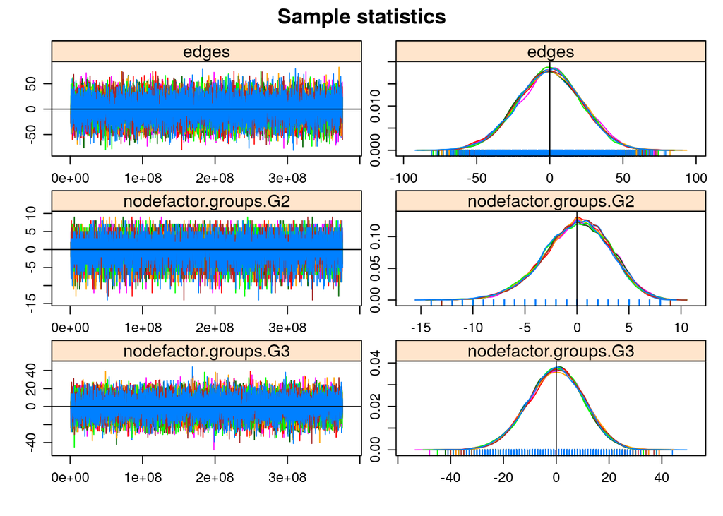

```
##
## MCMC diagnostics shown here are from the last round of simulation, prior to computation of final parameter estimates. Because the final estimates are refinements of those used for this simulation run, these diagnostics may understate model performance. To directly assess the performance of the fi…
```

### Summary of model fit

```r
summary(est.i.testriskg_fakegroups[[1]])
```

```
##
## ==========================
## Summary of model fit
## ==========================
##
## Formula:   nw ~ edges + nodefactor("groups", base = 4)
## <environment: 0x564f3558d8a8>
##
## Iterations:  2 out of 400
##
## Monte Carlo MLE Results:
##                      Estimate Std. Error MCMC % z value Pr(>|z|)
## edges                -9.02644    0.05164      0 -174.81   <1e-04 ***
## nodefactor.groups.G1     -Inf    0.00000      0    -Inf   <1e-04 ***
## nodefactor.groups.G2 -4.44038    0.31606      0  -14.05   <1e-04 ***
## nodefactor.groups.G3 -2.13832    0.10589      0  -20.20   <1e-04 ***
## ---
## Signif. codes:  0 '***' 0.001 '**' 0.01 '*' 0.05 '.' 0.1 ' ' 1
##
## Log-likelihood was not estimated for this fit.
## To get deviances, AIC, and/or BIC from fit `object$fit` run
##   > object$fit<-logLik(object$fit, add=TRUE)
## to add it to the object or rerun this function with eval.loglik=TRUE.
##
##  Warning: The following terms have infinite coefficient estimates:
##   nodefactor.groups.G1
##
## Dissolution Coefficients
## =======================
## Dissolution Model: ~offset(edges)
## Target Statistics: 1
## Crude Coefficient: -Inf
## Mortality/Exit Rate: 0
## Adjusted Coefficient: -Inf
```

### Network diagnostics

```r
(dx2 <- netdx(est.i.testriskg_fakegroups[[1]], nsims = 10, nsteps = 1000, ncores = 4, set.control.ergm = control.simulate.ergm(MCMC.interval = 1e+5, MCMC.burnin = 1e+6)))
```

```
##
## Network Diagnostics
## -----------------------
## - Simulating 10 networks
## - Calculating formation statistics
## - Calculating duration statistics
## - Calculating dissolution statistics
##
```

```
## EpiModel Network Diagnostics
## =======================
## Diagnostic Method: Dynamic
## Simulations: 10
## Time Steps per Sim: 1000
##
## Formation Diagnostics
## -----------------------
##                       Target Sim Mean Pct Diff Sim SD
## edges                479.159  411.941   -0.140 36.119
## nodefactor.groups.G1   0.000    0.000      NaN  0.000
## nodefactor.groups.G2  10.000    9.981   -0.002  3.197
## nodefactor.groups.G3 100.000  100.086    0.001 10.633
##
## Dissolution Diagnostics
## -----------------------
##                Target Sim Mean Pct Diff Sim SD
## Edge Duration       1        1        0      0
## Pct Edges Diss      1        1        0      0
```

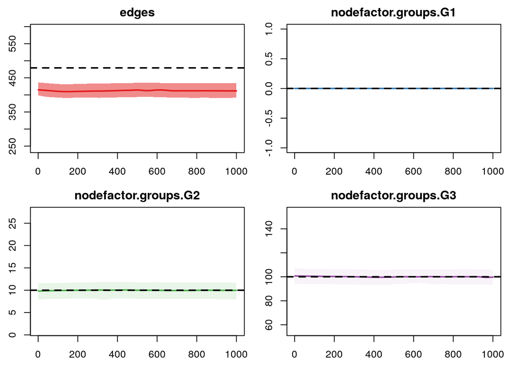

```r
plot(dx2, type="formation")
```

```r
plot(dx2, type="duration")
```

```r
plot(dx2, type="dissolution")
```

## 3. Edges + nodefactor(“group”, base=1)

This model uses the made-up four risk groups with the lowest quartile set to the reference group.

### Model terms and control settings

| Terms | Target stats |
| --- | --- |
| edges | 479.2 |
| nodefactor.groups.G2 | 10.0 |
| nodefactor.groups.G3 | 100.0 |
| nodefactor.groups.G4 | 848.3 |

The control settings for these models are:

```r
set.control.ergm = control.ergm(MCMC.interval = 1e+5,
                                MCMC.samplesize = 7500,
                                MCMC.burnin = 1e+6,
                                MPLE.max.dyad.types = 1e+7,
                                MCMLE.maxit = 400,
                                parallel = np/2,
                                parallel.type="PSOCK"))
```

### MCMC diagnostics

```
## Sample statistics summary:
##
## Iterations = 1e+06:375900000
## Thinning interval = 1e+05
## Number of chains = 8
## Sample size per chain = 3750
##
## 1. Empirical mean and standard deviation for each variable,
##    plus standard error of the mean:
##
##                          Mean     SD Naive SE Time-series SE
## edges                -0.21798 21.886  0.12636        0.12581
## nodefactor.groups.G2 -0.06347  3.187  0.01840        0.01834
## nodefactor.groups.G3 -0.20767 10.528  0.06078        0.06047
## nodefactor.groups.G4 -0.16483 39.974  0.23079        0.22949
##
## 2. Quantiles for each variable:
##
##                        2.5%    25%    50%   75% 97.5%
## edges                -43.84 -14.84 0.1586 14.16 42.16
## nodefactor.groups.G2  -7.00  -2.00 0.0000  2.00  6.00
## nodefactor.groups.G3 -21.00  -7.00 0.0000  7.00 20.00
## nodefactor.groups.G4 -79.68 -26.68 0.3172 27.32 78.32
##
##
## Sample statistics cross-correlations:
##                          edges nodefactor.groups.G2 nodefactor.groups.G3
## edges                1.0000000           0.15117566           0.43342285
## nodefactor.groups.G2 0.1511757           1.00000000           0.03883959
## nodefactor.groups.G3 0.4334229           0.03883959           1.00000000
## nodefactor.groups.G4 0.9688035           0.07559459           0.20813867
##                      nodefactor.groups.G4
## edges                          0.96880352
## nodefactor.groups.G2           0.07559459
## nodefactor.groups.G3           0.20813867
## nodefactor.groups.G4           1.00000000
##
## Sample statistics auto-correlation:
## Chain 1
##                  edges nodefactor.groups.G2 nodefactor.groups.G3
```

[output cut: 233 more lines]

```
##
## Fraction in 1st window = 0.1
## Fraction in 2nd window = 0.5
##
##                edges nodefactor.groups.G2 nodefactor.groups.G3
##               0.7437              -0.3271               0.2863
## nodefactor.groups.G4
##               0.7744
##
## Individual P-values (lower = worse):
##                edges nodefactor.groups.G2 nodefactor.groups.G3
##            0.4570651            0.7435657            0.7746193
## nodefactor.groups.G4
##            0.4386751
## Joint P-value (lower = worse):  0.9328955 .
```

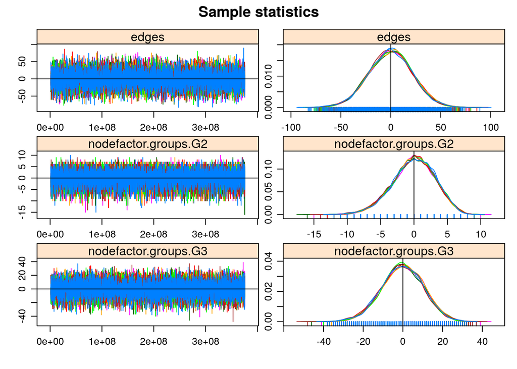

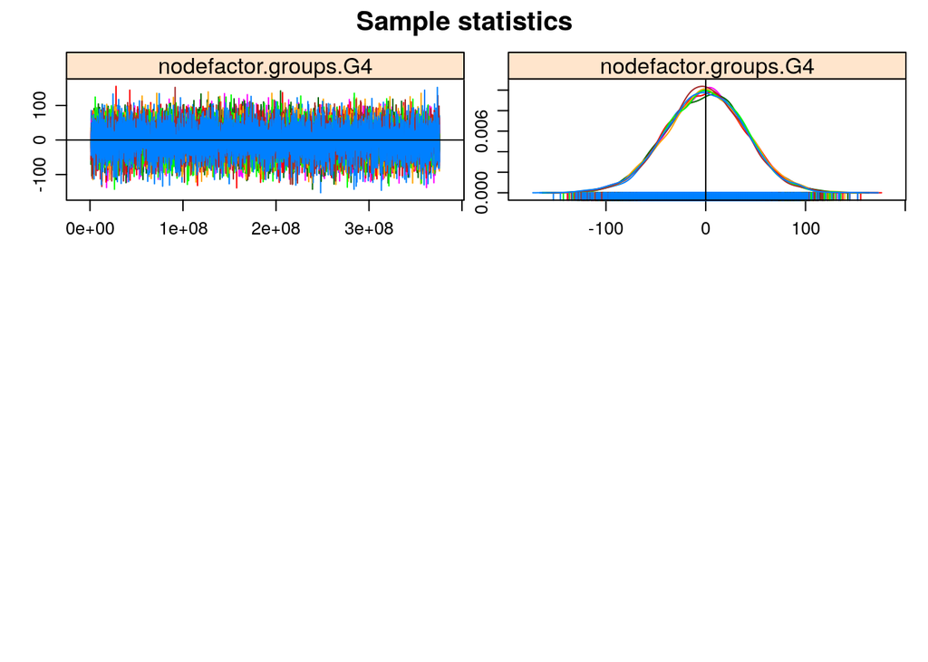

```
##
## MCMC diagnostics shown here are from the last round of simulation, prior to computation of final parameter estimates. Because the final estimates are refinements of those used for this simulation run, these diagnostics may understate model performance. To directly assess the performance of the fi…
```

### Summary of model fit

```r
summary(est.i.testriskg_fakegroups[[2]])
```

```
##
## ==========================
## Summary of model fit
## ==========================
##
## Formula:   nw ~ edges + nodefactor("groups", base = 1)
## <environment: 0x564f410a5ad8>
##
## Iterations:  14 out of 400
##
## Monte Carlo MLE Results:
##                      Estimate Std. Error MCMC % z value Pr(>|z|)
## edges                  -45.44         NA     NA      NA       NA
## nodefactor.groups.G2    13.76         NA     NA      NA       NA
## nodefactor.groups.G3    16.07         NA     NA      NA       NA
## nodefactor.groups.G4    18.21         NA     NA      NA       NA
##
## Log-likelihood was not estimated for this fit.
## To get deviances, AIC, and/or BIC from fit `object$fit` run
##   > object$fit<-logLik(object$fit, add=TRUE)
## to add it to the object or rerun this function with eval.loglik=TRUE.
##
## Dissolution Coefficients
## =======================
## Dissolution Model: ~offset(edges)
## Target Statistics: 1
## Crude Coefficient: -Inf
## Mortality/Exit Rate: 0
## Adjusted Coefficient: -Inf
```

### Network diagnostics

```r
(dx3 <- netdx(est.i.testriskg_fakegroups[[2]], nsims = 10, nsteps = 1000, ncores = 4, set.control.ergm = control.simulate.ergm(MCMC.interval = 1e+5, MCMC.burnin = 1e+6)))
```

```
##
## Network Diagnostics
## -----------------------
## - Simulating 10 networks
## - Calculating formation statistics
## - Calculating duration statistics
## - Calculating dissolution statistics
##
```

```
## EpiModel Network Diagnostics
## =======================
## Diagnostic Method: Dynamic
## Simulations: 10
## Time Steps per Sim: 1000
##
## Formation Diagnostics
## -----------------------
##                       Target Sim Mean Pct Diff Sim SD
## edges                479.159  412.640   -0.139 36.234
## nodefactor.groups.G2  10.000   10.021    0.002  3.207
## nodefactor.groups.G3 100.000  100.040    0.000 10.593
## nodefactor.groups.G4 848.317  715.218   -0.157 70.319
##
## Dissolution Diagnostics
## -----------------------
##                Target Sim Mean Pct Diff Sim SD
## Edge Duration       1        1        0      0
## Pct Edges Diss      1        1        0      0
```

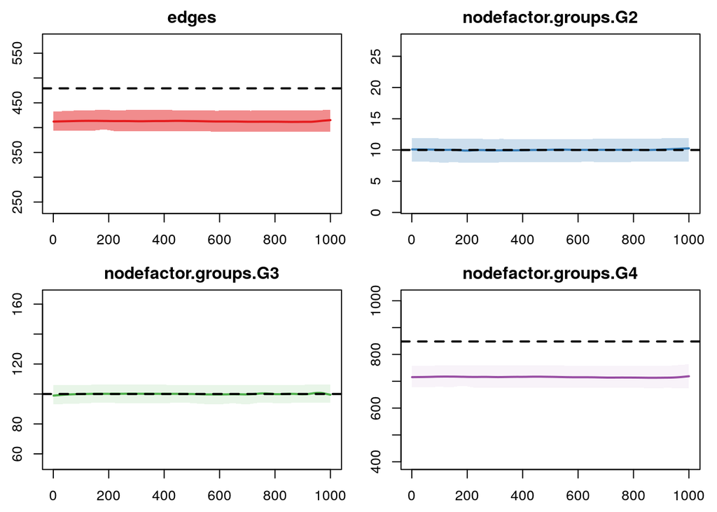

```r
plot(dx3, type="formation")
```

```r
plot(dx3, type="duration")
```

```r
plot(dx3, type="dissolution")
```

## 4. Edges + nodefactor(“group”, base=4) + offset(nodematch(“role.class”))

This model uses the-made up four risk groups with the highest quartile set to the reference group and with the offset for role class.

### Model terms and control settings

| Terms | Target stats |
| --- | --- |
| edges | 479.2 |
| nodefactor.groups.G1 | 0.0 |
| nodefactor.groups.G2 | 10.0 |
| nodefactor.groups.G3 | 100.0 |
| nodematch.role.class.I | -Inf |
| nodematch.role.class.R | -Inf |

The control settings for these models are:

```r
set.control.ergm = control.ergm(MCMC.interval = 1e+5,
                                MCMC.samplesize = 7500,
                                MCMC.burnin = 1e+6,
                                MPLE.max.dyad.types = 1e+7,
                                MCMLE.maxit = 400,
                                parallel = np/2,
                                parallel.type="PSOCK"))
```

### MCMC diagnostics

```
## Sample statistics summary:
##
## Iterations = 1e+06:375900000
## Thinning interval = 1e+05
## Number of chains = 8
## Sample size per chain = 3750
##
## 1. Empirical mean and standard deviation for each variable,
##    plus standard error of the mean:
##
##                          Mean     SD Naive SE Time-series SE
## edges                -0.34738 21.823  0.12599        0.12561
## nodefactor.groups.G2 -0.06277  3.178  0.01835        0.01831
## nodefactor.groups.G3  0.12113 10.459  0.06039        0.06024
##
## 2. Quantiles for each variable:
##
##                        2.5%    25%    50%   75% 97.5%
## edges                -43.84 -14.84 0.1586 14.16 42.16
## nodefactor.groups.G2  -7.00  -2.00 0.0000  2.00  6.00
## nodefactor.groups.G3 -21.00  -7.00 0.0000  7.00 20.00
##
##
## Sample statistics cross-correlations:
##                          edges nodefactor.groups.G2 nodefactor.groups.G3
## edges                1.0000000           0.14480028           0.43478609
## nodefactor.groups.G2 0.1448003           1.00000000           0.02862766
## nodefactor.groups.G3 0.4347861           0.02862766           1.00000000
##
## Sample statistics auto-correlation:
## Chain 1
##                  edges nodefactor.groups.G2 nodefactor.groups.G3
## Lag 0      1.000000000          1.000000000         1.0000000000
## Lag 1e+05  0.013204006         -0.003111762         0.0144588183
## Lag 2e+05  0.029924068         -0.013615185         0.0136659323
## Lag 3e+05  0.015121871         -0.002344283        -0.0003033402
## Lag 4e+05  0.009630431         -0.017860074         0.0057027631
## Lag 5e+05 -0.002867327          0.010015002         0.0060167005
## Chain 2
##                  edges nodefactor.groups.G2 nodefactor.groups.G3
```

[output cut: 137 more lines]

```
##                edges nodefactor.groups.G2 nodefactor.groups.G3
##            0.1085023            0.8781011            0.5744843
## Joint P-value (lower = worse):  0.3309128 .
## Chain 8
##
## Fraction in 1st window = 0.1
## Fraction in 2nd window = 0.5
##
##                edges nodefactor.groups.G2 nodefactor.groups.G3
##               0.7443               1.2313               2.6349
##
## Individual P-values (lower = worse):
##                edges nodefactor.groups.G2 nodefactor.groups.G3
##          0.456667351          0.218204081          0.008417244
## Joint P-value (lower = worse):  0.04301344 .
```

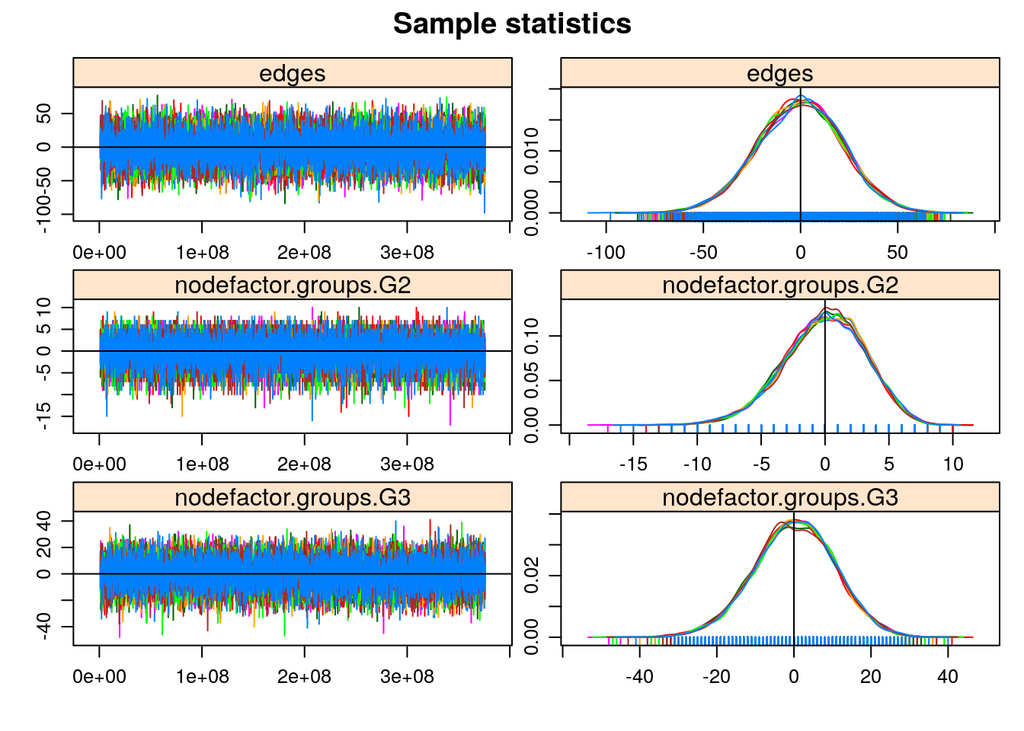

```
##
## MCMC diagnostics shown here are from the last round of simulation, prior to computation of final parameter estimates. Because the final estimates are refinements of those used for this simulation run, these diagnostics may understate model performance. To directly assess the performance of the fi…
```

### Summary of model fit

```r
summary(est.i.testriskg_fakegroups[[3]])
```

```
##
## ==========================
## Summary of model fit
## ==========================
##
## Formula:   nw ~ edges + nodefactor("groups", base = 4) + offset(nodematch("role.class",
##     diff = TRUE, keep = 1:2))
## <environment: 0x564f4cc322a0>
##
## Iterations:  2 out of 400
##
## Monte Carlo MLE Results:
##                                Estimate Std. Error MCMC % z value Pr(>|z|)
## edges                          -8.95637    0.05144      0 -174.10   <1e-04
## nodefactor.groups.G1               -Inf    0.00000      0    -Inf   <1e-04
## nodefactor.groups.G2           -4.43633    0.31827      0  -13.94   <1e-04
## nodefactor.groups.G3           -2.14084    0.10625      0  -20.15   <1e-04
## offset(nodematch.role.class.I)     -Inf    0.00000      0    -Inf   <1e-04
## offset(nodematch.role.class.R)     -Inf    0.00000      0    -Inf   <1e-04
##
## edges                          ***
## nodefactor.groups.G1           ***
## nodefactor.groups.G2           ***
## nodefactor.groups.G3           ***
## offset(nodematch.role.class.I) ***
## offset(nodematch.role.class.R) ***
## ---
## Signif. codes:  0 '***' 0.001 '**' 0.01 '*' 0.05 '.' 0.1 ' ' 1
##
## Log-likelihood was not estimated for this fit.
## To get deviances, AIC, and/or BIC from fit `object$fit` run
##   > object$fit<-logLik(object$fit, add=TRUE)
## to add it to the object or rerun this function with eval.loglik=TRUE.
##
##  Warning: The following terms have infinite coefficient estimates:
##   nodefactor.groups.G1
##
##  The following terms are fixed by offset and are not estimated:
##   offset(nodematch.role.class.I) offset(nodematch.role.class.R)
##
##
## Dissolution Coefficients
## =======================
## Dissolution Model: ~offset(edges)
## Target Statistics: 1
## Crude Coefficient: -Inf
## Mortality/Exit Rate: 0
## Adjusted Coefficient: -Inf
```

### Network diagnostics

```r
(dx4 <- netdx(est.i.testriskg_fakegroups[[3]], nsims = 10, nsteps = 1000, ncores = 4, set.control.ergm = control.simulate.ergm(MCMC.interval = 1e+5, MCMC.burnin = 1e+6)))
```

```
##
## Network Diagnostics
## -----------------------
## - Simulating 10 networks
## - Calculating formation statistics
## - Calculating duration statistics
## - Calculating dissolution statistics
##
```

```
## EpiModel Network Diagnostics
## =======================
## Diagnostic Method: Dynamic
## Simulations: 10
## Time Steps per Sim: 1000
##
## Formation Diagnostics
## -----------------------
##                                 Target Sim Mean Pct Diff Sim SD
## edges                          479.159  404.681   -0.155 37.616
## nodefactor.groups.G1                NA    0.000       NA  0.000
## nodefactor.groups.G2            10.000   10.031    0.003  3.188
## nodefactor.groups.G3           100.000  100.173    0.002 10.529
## offset(nodematch.role.class.I)      NA    0.000       NA  0.000
## offset(nodematch.role.class.R)      NA    0.000       NA  0.000
##
## Dissolution Diagnostics
## -----------------------
##                Target Sim Mean Pct Diff Sim SD
## Edge Duration       1        1        0      0
## Pct Edges Diss      1        1        0      0
```

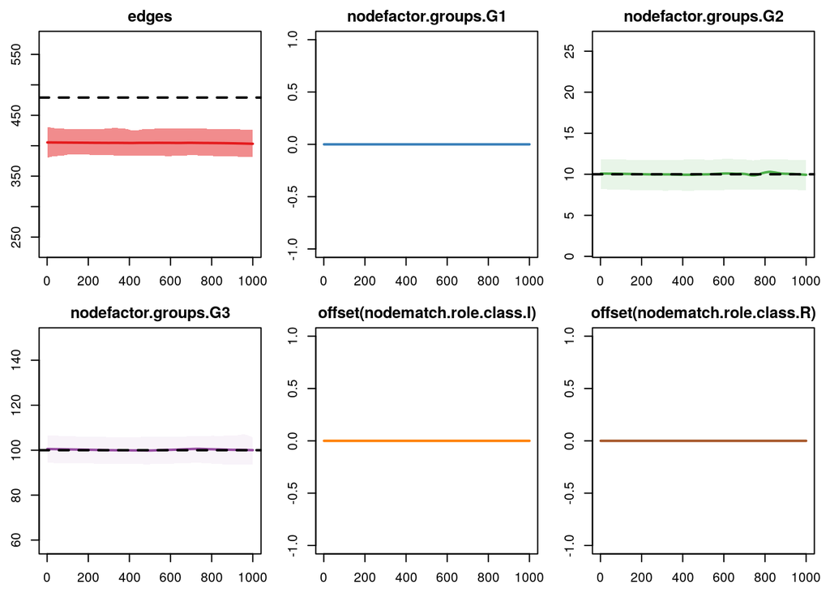

```r
plot(dx4, type="formation")
```

```r
plot(dx4, type="duration")
```

```r
plot(dx4, type="dissolution")
```